# cue/nocue

Ingunn Lilja Bergsdóttir

6/16/2020

Samantekt fyrir breytur í gagnatöflunni.

```
##     answerId       lectureId       studentId       questionId
##  11     :    1   2547   : 1790   14     :  236   1436   : 1241
##  28     :    1   361    : 1739   285    :  167   1359   : 1073
##  105    :    1   360    : 1644   14371  :  141   10022  : 1066
##  135    :    1   7      : 1467   13521  :  129   1708   :  869
##  265    :    1   6      : 1335   12948  :  124   504    :  827
##  273    :    1   21     : 1269   328    :  111   1772   :  741
##  (Other):28630   (Other):19392   (Other):27728   (Other):22819
##                                               plonePath         grade
##  /tutor-web/math/math104-2calc/lecture52/Ag80q103  : 1241   Min.   :0.000
##  /tutor-web/math/math104-2calc/lecture51/Ag20q23   : 1073   1st Qu.:3.000
##  /tutor-web/math/math099.0/lec050500/qInt4004      : 1066   Median :5.250
##  /tutor-web/math/math104-3calc/lecture10/Hg90qD02  :  869   Mean   :5.129
##  /tutor-web/math/math104-1calc/lecture10/Qgen-q7006:  827   3rd Qu.:7.500
##  /tutor-web/math/math104-3calc/lecture20/Ag90q04   :  741   Max.   :9.999
##  (Other)                                           :22819   NA's   :45
##     correct                     timeStart                    timeEnd
##  Min.   :0.0000   2014-10-26 00:38:17:    9   2014-10-26 00:38:20:    9
##  1st Qu.:0.0000   2014-11-06 09:53:09:    5   2014-11-06 09:53:25:    5
##  Median :1.0000   2014-11-06 09:59:06:    5   2014-11-06 09:59:56:    5
##  Mean   :0.7372   2016-08-25 11:28:20:    4   2016-08-25 11:25:38:    4
##  3rd Qu.:1.0000   2016-08-25 15:22:10:    4   2016-08-31 06:54:33:    4
##  Max.   :1.0000   2016-08-31 06:54:25:    4   2016-08-31 06:59:42:    4
##                   (Other)            :28605   (Other)            :28605
##  cue              qName
##  0:22553   Q65       : 2010
##  1: 6083   Ag80q103  : 1881
##            qInt4004  : 1782
##            Qgen-q0111: 1761
##            Hg90qD02  : 1499
##            Ag20q23   : 1149
##            (Other)   :18554
```

# Lýsandi tölfræði

Stöplarit og tíðnitafla sem sýnir fjölda réttra og rangra svara eftir cue eða ekki cue spurningu.

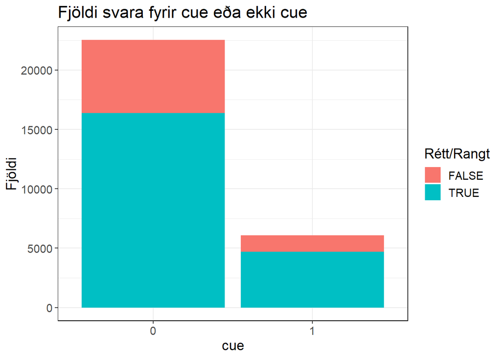

Tíðnitafla

```
## Margins computed over dimensions
## in the following order:
## 1: correct
## 2: cue
```

Tíðnitafla

|  | Án cue | Með cue | Heild |
| --- | --- | --- | --- |
| Rangt | 6154 | 1372 | 7526 |
| Rétt | 16399 | 4711 | 21110 |
| Heild | 22553 | 6083 | 28636 |

Tafla sem sýnir meðaleinkunn fyrir hvorn flokk þar sem einkunnin byggir á fjölda réttra svara deilt með fjölda svara.

Meðaleinkunn

| Cue | Meðaleinkunn |
| --- | --- |
| 0 | 7.271317 |
| 1 | 7.744534 |

Meðaleinkunn fyrir vísbendingaspurningar er um 0.5 hærri en fyrir aðrir spurningar.

Auka rammi búin til sem eru bara spurningarnar og meðaleiknunnin á þeim eftir cue eða ekki. Gert til að vera með betri grade breytu. Fjöldi réttra svara deilt með fjölda spurninga og nýja grade breytan er þvi meðaltal. Ramminn skýrður medal

Mynd sem sýnir meðaltöl fyrir cue og ekki cue fyrir hverja spurningu.

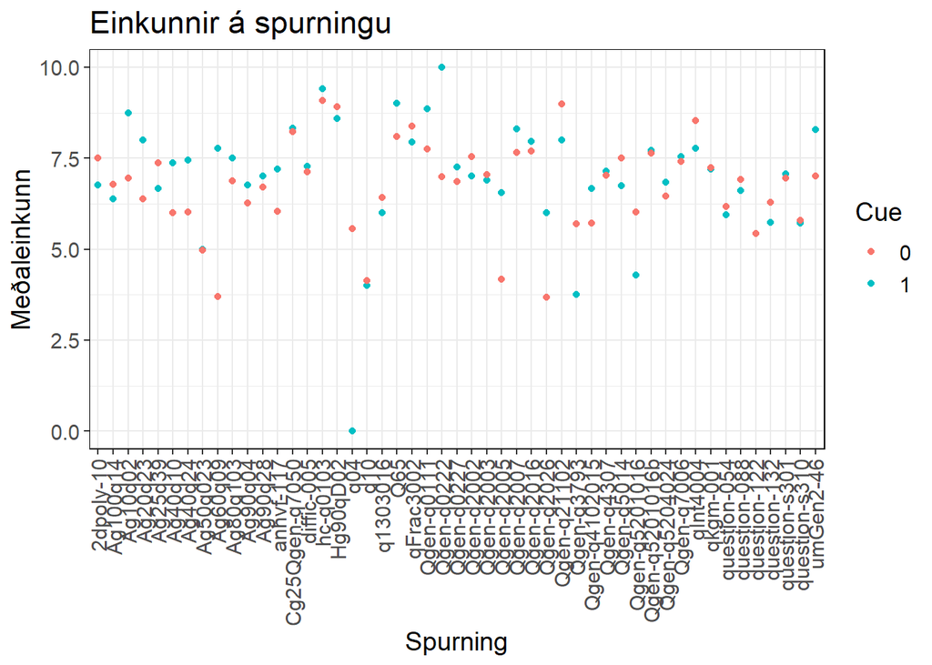

Skoða q04 spurninguna betur þar sem meðaleinkunnin 0 er undarleg.

```
## [1] 13
```

13 svör til við þessari spurningu þar sem cue er aldrei rétt í 4 tilvikum. Skoða hvort það sé í lagi að eyða henni og öðrum spurningum með minna en 20 svör skráð út.

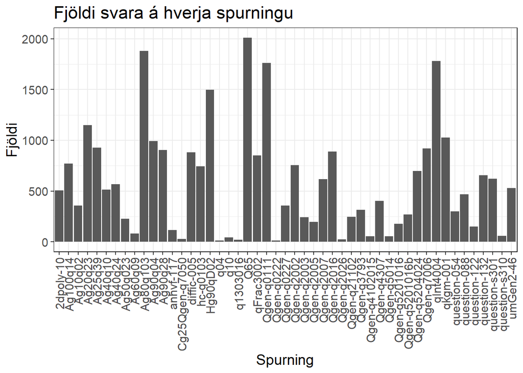

Sjáum að q04 hefur mjög fá svör samanborið við aðrar spurningar.

Svipuð mynd miðuð við að sýna gengi á hverri spurningu.

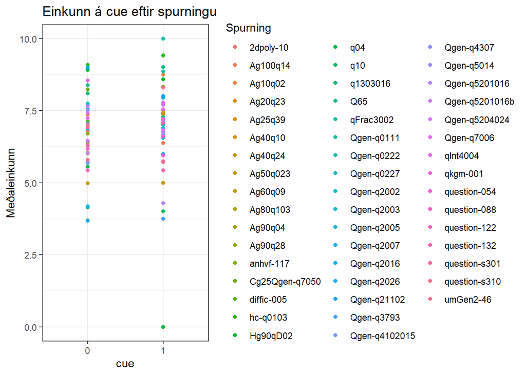

Cue virðist ganga betur.

Kassarit til að sýna meðaltölin og miðgildi á milli hópa.

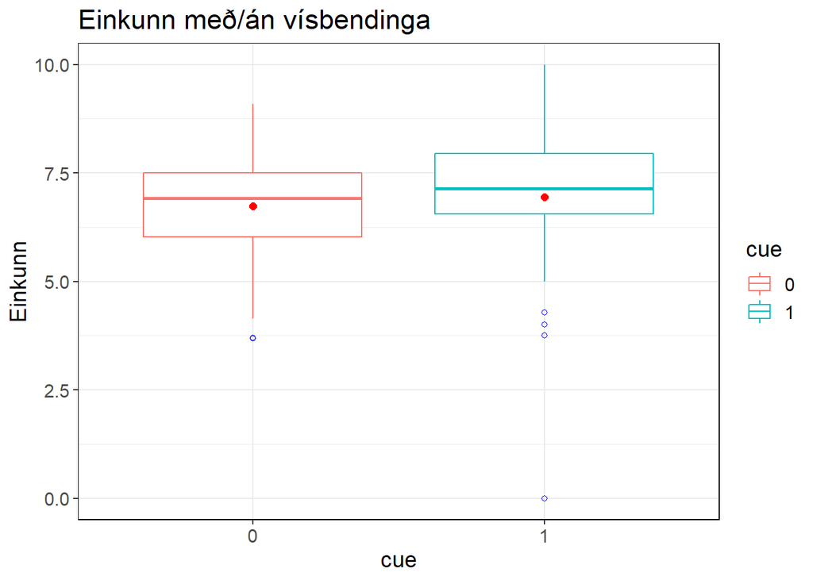

Örlítið hærra miðgildi fyrir cue - munar ekki miklu. Fjórðungamörkin eru þó hærri

Vil skoða hvort það skipti meira máli fyrir fólk með lægri eða hærri einkunnir að fá cue sp.

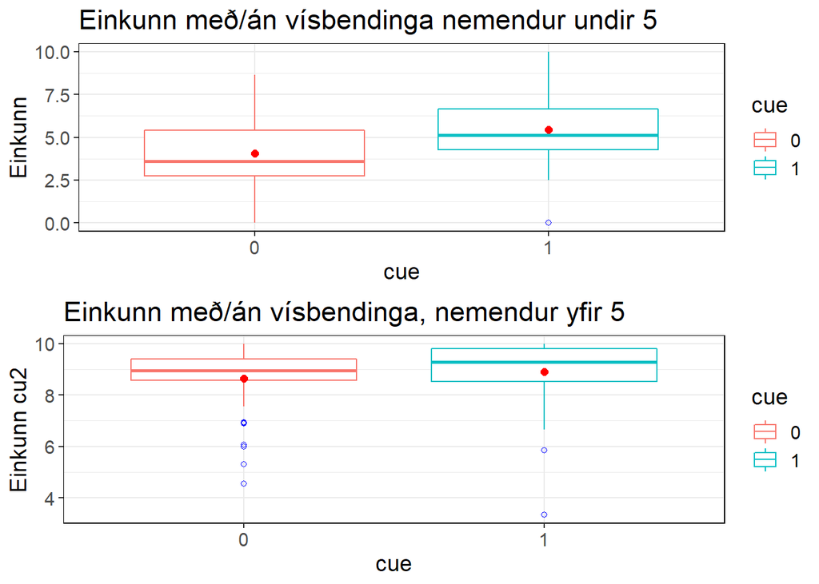

Miklu meiri munur á cue og ekki cue fyrir nemendur með einkunn, eftir spurningu, lægri en 5.

## Töflur sem sýna fjórðungamörk einkunna fyrir svör með og án cue.

Cue svör:

Fjórðungamörk fyrir cue spurningar

|  | Meðaleinkunn |
| --- | --- |
| 0% | 0.000000 |
| 25% | 6.547619 |
| 50% | 7.142857 |
| 75% | 7.947368 |
| 100% | 10.000000 |

Svör án cue:

Fjórðungamörk fyrir án cue spurningar

|  | Meðaleinkunn |
| --- | --- |
| 0% | 3.684210 |
| 25% | 6.024845 |
| 50% | 6.909976 |
| 75% | 7.505669 |
| 100% | 9.085714 |

Cue kemur betur út en munar mjög litlu.

Hutfalla tafla

Hlutföll

|  | Án cue | Með cue |
| --- | --- | --- |
| Rangt | 0.273 | 0.226 |
| Rétt | 0.727 | 0.774 |

Hlutfallslega fleiri rétt svör í cue flokknum.

Kannað hvort það sé rétt að það séu hlutfallslega fleiri rétt svör í cue hópnum með prop.test.

```
##
##  2-sample test for equality of proportions with continuity correction
##
## data:  table(cue_nocue$correct, cue_nocue$cue)
## X-squared = 55.13, df = 1, p-value = 1.128e-13
## alternative hypothesis: two.sided
## 95 percent confidence interval:
##  0.03039817 0.05132788
## sample estimates:
##    prop 1    prop 2
## 0.8176986 0.7768356
```

Samkvæmt þessu er marktækur munur á hlutföllunum. Semsagt hlutfallslega betra gengi á cue spurningum.

# Líkanagerð

Línulegt aðhvarfsgreiningar líkan fyrir medal töfluna. Breytur eru meðaleinkunn á spurningu og cue.

| term | sumsq | df | statistic | p.value |
| --- | --- | --- | --- | --- |
| (Intercept) | 2219.4895 | 1 | 1033.2083689 | 0.0000000 |
| cue | 1.1740 | 1 | 0.5465159 | 0.4615486 |
| Residuals | 206.2227 | 96 | NA | NA |

Ekki marktækur munur á meðaltölunum eftir cue eða ekki cue.

# Líkan 1

Tvíkosta aðhvarfsgreiningar líkan fyrir cue_nocue gagnaramman. Glm þar sem correct er tvíkosta breyta.

Anova tafla fyrir marktækni.

| term | statistic | df | p.value |
| --- | --- | --- | --- |
| cue | 56.72852 | 1 | 0 |

Marktækur munur á meðaltölum fyrir cue. Kemur á óvart.

# Gæði líkans 1

Calibration (kvörðun)

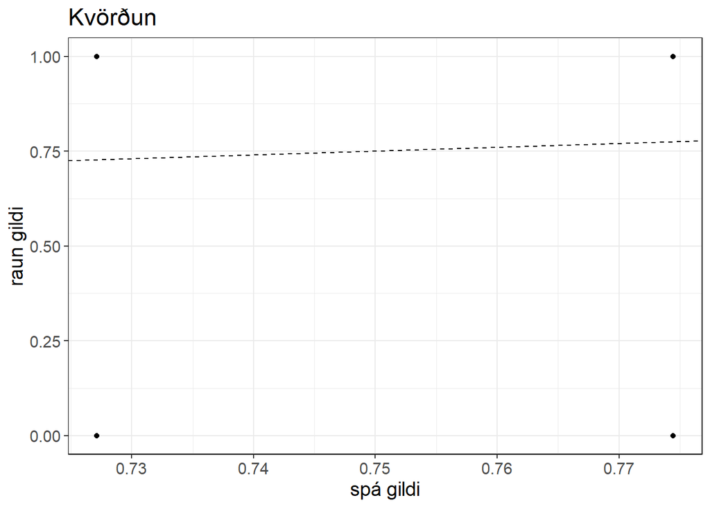

Ekkert að marka þetta.

ROC kúrfa með AUC og Brier gildum

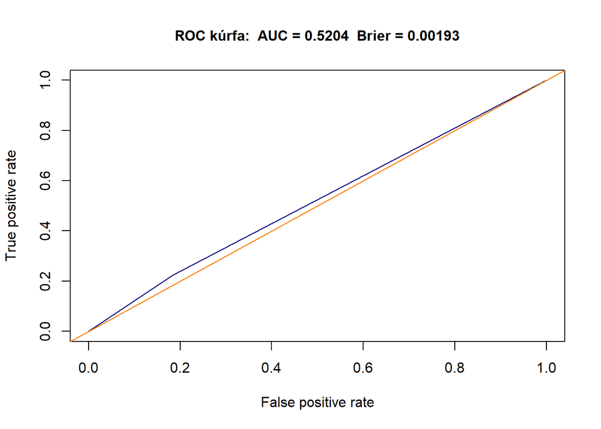

ROC kúrfa sem lítur ekki vel út og og AUC sem er mjög nálægt 0.5 og þá þvi að vera alveg ómarktækt. Fullkomin AUC og Brier gildi eru nálægt 1.

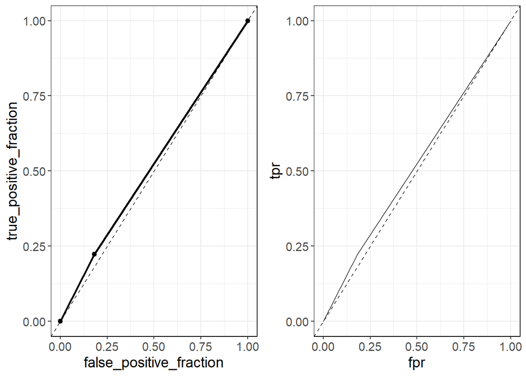

# Líkan 2

Hafa cue og qName áhrif á correct breytuna ?

| term | statistic | df | p.value |
| --- | --- | --- | --- |
| cue | 28.59043 | 1 | 1e-07 |
| qName | 1310.39266 | 48 | 0e+00 |

Marktækt fyrir bæði cue og qName miðað við p-gildin.

# Gæði líkans 2

Calibration (kvörðun)

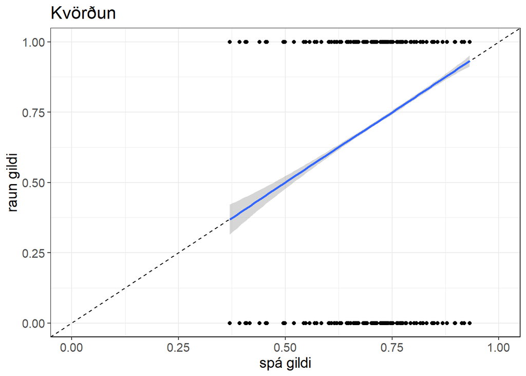

Nokkuð gott.

ROC kúrfa með AUC og brier skori.

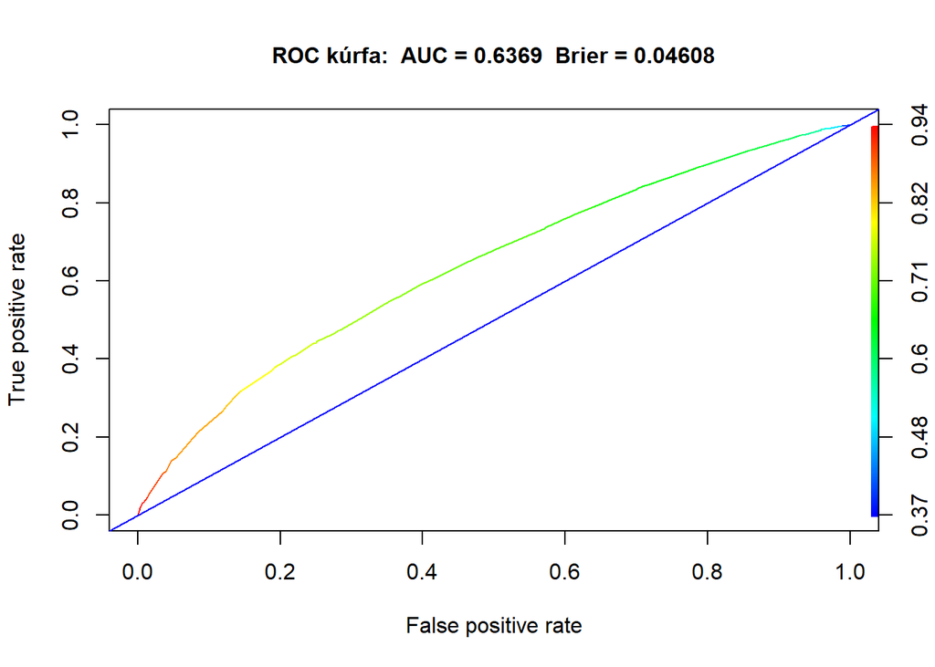

ROC kúrfa sem lítur ekki vel út en miklu betri en í glm1. AUC gildið er komið uppí 0.6369 sem er ekki galið en brier gildið er mjög lágt.

# Líkön 3

Breytur eru cue, qName og interaction þar á milli.

| term | statistic | df | p.value |
| --- | --- | --- | --- |
| cue | 1.537641 | 1 | 0.2149693 |
| qName | 1050.375908 | 48 | 0.0000000 |
| cue:qName | 132.232204 | 48 | 0.0000000 |

cue hefur ekki marktæk áhrif en qName og interaction breytan hafa marktæk áhrif.

Calibration (kvörðun)

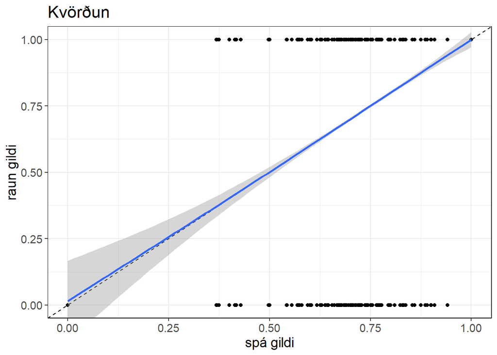

Best hingað til. Lítur mjög vel út

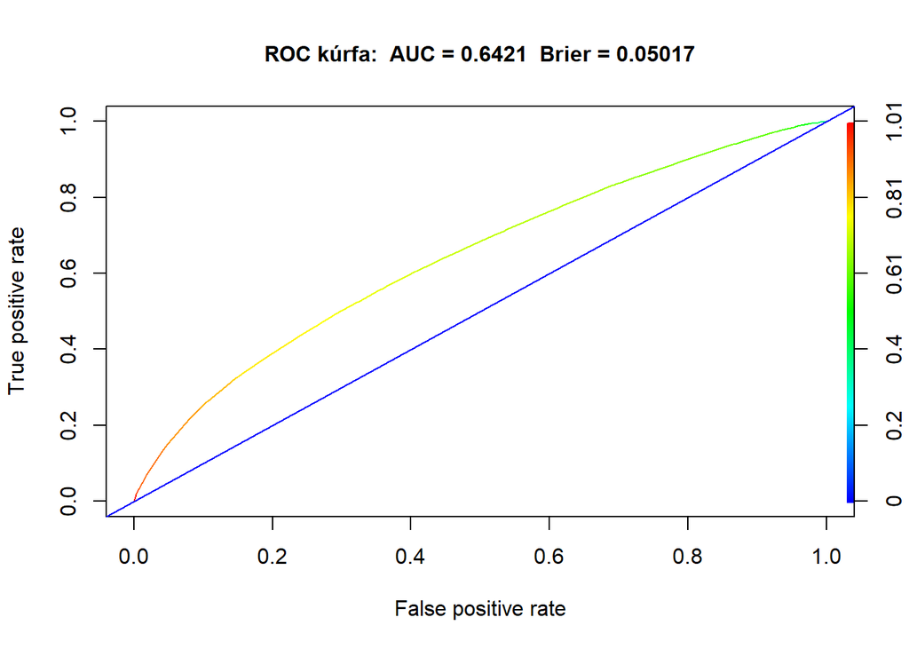

Örlítil bæting á bæði AUC og brier frá líkani 2. Brier gildið er ennþá allt of lágt.

## Mixed effect líkön

Hvert svar í gagnarammanum er tilgreint nemanda. Nemendur hafa svarað mis oft eins og sést hér:

```
## [1] 236
```

```
## [1] 748
```

```
## [1] 6
```

Mest eru 236 svör tengd við einn nemanda, 748 nemendur hafa aðeins eitt svar skráð og 6 nemendur hafa svarað jafn oft eða meira en 100 sinnum. Miðað við það eru til dæmis amk 600 svör af 28636 svörum í heildina frá sömu 6 nemendunum. Mælingar eiga að vera óháðar fyrir línulega aðhvarfsgreiningu sem þær eru ef hver nemandi hefur eitt svar en 100 svör frá sama nemandanum eru innbyrðis háð og því þarf að setja upp mixed effect líkan til að leiðrétta fyrir þetta.

# Mixed effect líkan 1

| term | statistic | df | p.value |
| --- | --- | --- | --- |
| (Intercept) | 2903.76020 | 1 | 0e+00 |
| cue | 25.80597 | 1 | 4e-07 |

Marktækt fyrir cue með mixed effect.

# Gæði mixed effeect líkans 1

Kvörðun

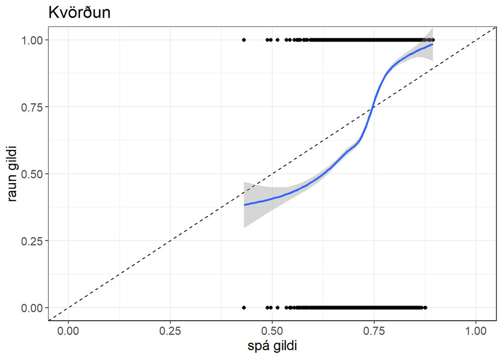

ROC kúrfa, AUC og brier gildi.

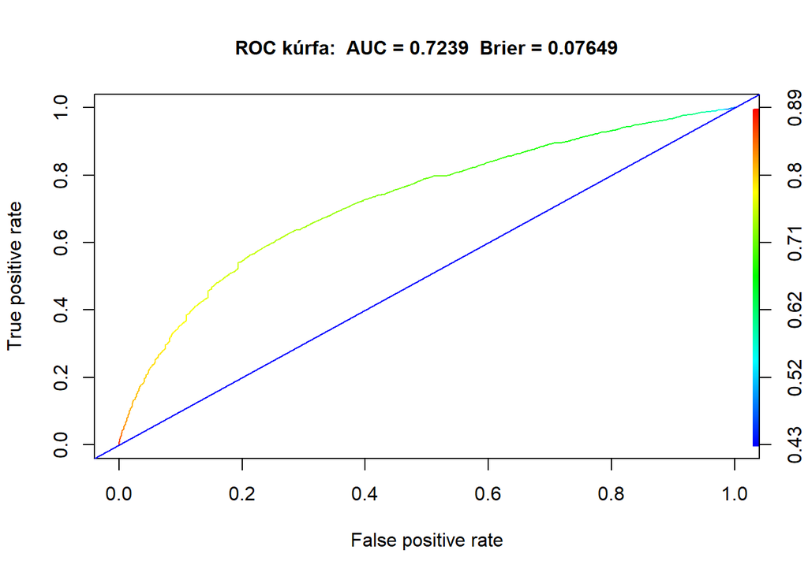

Mjög gott miðað við hingað til! Brier gildið reyndar arfa slakt ennþá.

# Líkan 2

| term | statistic | df | p.value |
| --- | --- | --- | --- |
| (Intercept) | 102.68741 | 1 | 0.0000000 |
| cue | 14.36673 | 1 | 0.0001504 |
| qName | 1170.45194 | 48 | 0.0000000 |

Marktækt fyrir cue og qName.

# Gæði mixed effect líkans 2

Kvörðun

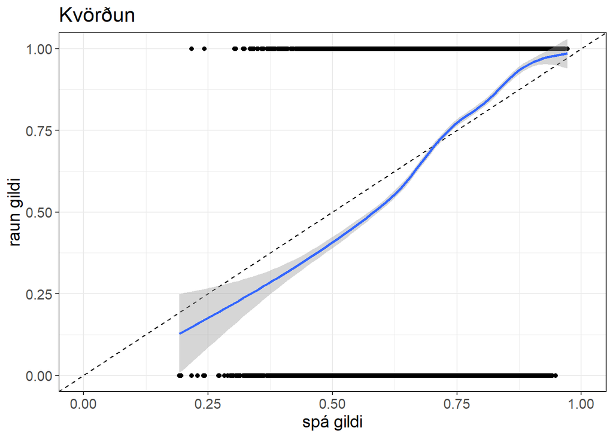

ROC kúrfa, AUC og brier.

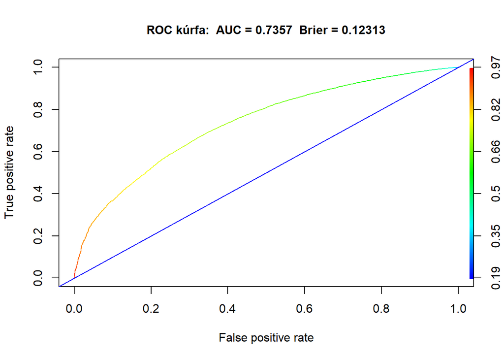

AUC komið uppí 0.7357 og brier í 0.12313 sem er það lang besta hingað til.

# Mixed effect líkan 3

Anova tafla.

| term | statistic | df | p.value |
| --- | --- | --- | --- |
| (Intercept) | 102.53477 | 1 | 0.0000000 |
| cue | 3.04862 | 1 | 0.0808058 |
| qName | 947.73285 | 48 | 0.0000000 |
| cue:qName | 119.74546 | 48 | 0.0000000 |

Marktækt fyrir qName og interaction á milli cue og qName.

# Gæði mixed effect líkans 3

Kvörðun

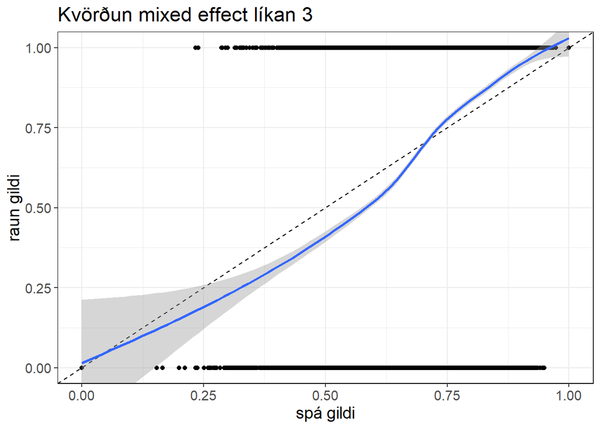

ROC kúrfa, AUC og brier gildi.

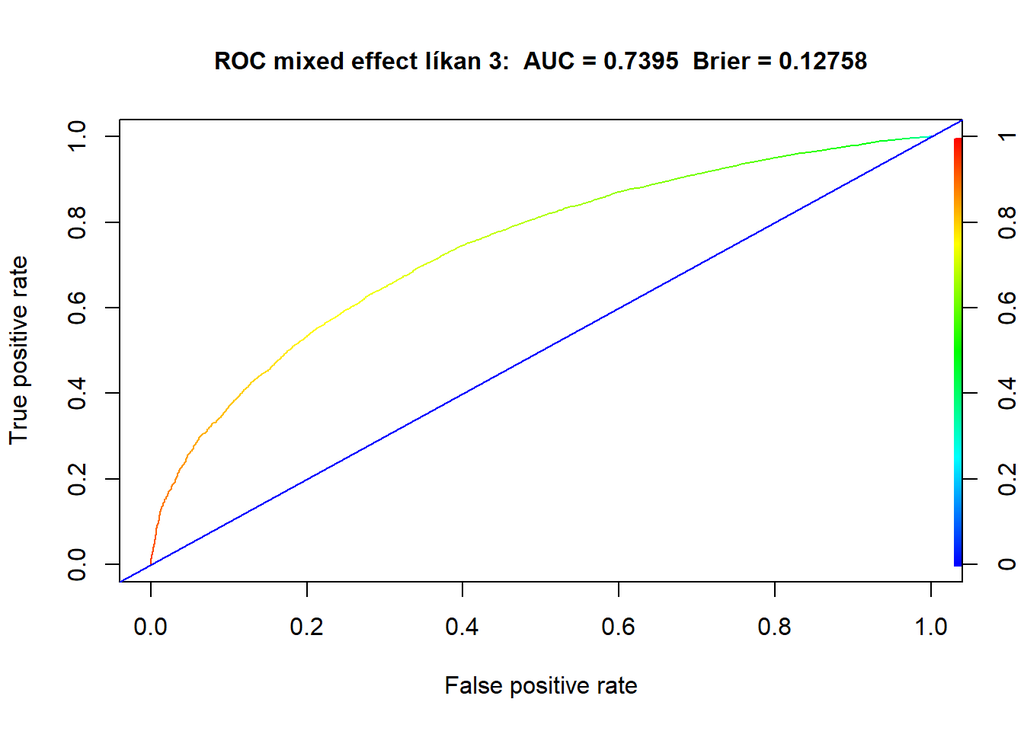

Mjög gott AUC gildi og langbesta brier gildi sem komið hefur upp hingað til.

Dreifni skurðpunkta við y-ás fyrir hvern nemanda í mixed effect líkaninu. Sýnir random effect.

A generic function to extract the conditional modes of the random effects from a fitted model object. For linear mixed models the conditional modes of the random effects are also the conditional means.

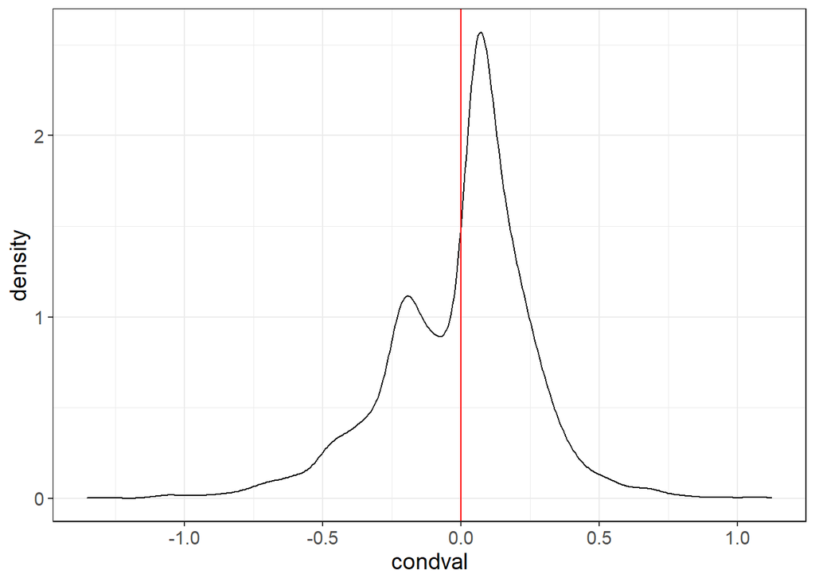